# Caloric_vs_alcohol

Group 13

23/11/2020

## Question

Is there a correlation between caloric intake and the number of alcoholic drinks consumed weekly?

## MOTIVATION

This question was chosen keeping the Nutrition database in mind. We wanted to analyze a relation between alcohol consumption and calorie intake because we are aware of the fact that a lot of alcohol is consumed by people all over the world. Now an interesting aspect arises, is there a correlation between caloric intake and the number of alcoholic drinks consumed weekly? Even though it is known that moderate alcohol drinkers tend to munch on food right when they start drinking, so that would lean us to thinking that there is some mind of correlation so let’s find out whether this is true using the nutrition dataset.

## Method

I will use linear regression to find out the answer to this question.

## Experiment

```r
library(tidyr)
library(tidyverse)
library(broom)

load("NutritionStudy.rda")

head(NutritionStudy)
```

```
##   ID Age Smoke Quetelet Vitamin Calories  Fat Fiber Alcohol Cholesterol
## 1  1  64    No  21.4838       1   1298.8 57.0   6.3     0.0       170.3
## 2  2  76    No  23.8763       1   1032.5 50.1  15.8     0.0        75.8
## 3  3  38    No  20.0108       2   2372.3 83.6  19.1    14.1       257.9
## 4  4  40    No  25.1406       3   2449.5 97.5  26.5     0.5       332.6
## 5  5  72    No  20.9850       1   1952.1 82.6  16.2     0.0       170.8
## 6  6  40    No  27.5214       3   1366.9 56.0   9.6     1.3       154.6
##   BetaDiet RetinolDiet BetaPlasma RetinolPlasma Gender VitaminUse PriorSmoke
## 1     1945         890        200           915 Female    Regular          2
## 2     2653         451        124           727 Female    Regular          1
## 3     6321         660        328           721 Female Occasional          2
## 4     1061         864        153           615 Female         No          2
## 5     2863        1209         92           799 Female    Regular          1
## 6     1729        1439        148           654 Female         No          2
```

We can clearly see that we have available data for Caloric intake and number of alcohol drinks consumed per week.

```r
dat <- NutritionStudy %>%
  select(Alcohol, Calories)
head(dat)
```

```
##   Alcohol Calories
## 1     0.0   1298.8
## 2     0.0   1032.5
## 3    14.1   2372.3
## 4     0.5   2449.5
## 5     0.0   1952.1
## 6     1.3   1366.9
```

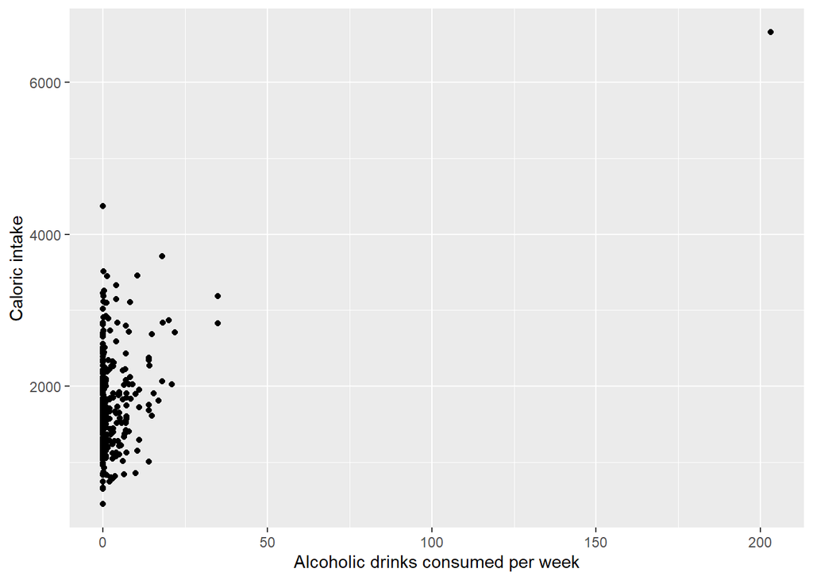

```r
dat %>%
  ggplot(mapping = aes(x = Alcohol,y = Calories)) + geom_point() +labs(x = "Alcoholic drinks consumed per week", y= "Caloric intake")
```

We should get rid of this outlier

```r
dat <- dat %>%
  filter(Alcohol < 70)
```

# Linear Regression

We want to know if there is a correlation between caloric intake and alcohol consumption. So we write the alternative as H_a>0

$$H_0 : B_1 = 0$$
$$H_a : B_1 >0$$

```r
dat <- dat %>%
  filter(Alcohol != 0)
```

```r
mod.fit <-lm(Calories ~ Alcohol , data=dat)

mod.fit %>%
  tidy()
```

```
## # A tibble: 2 x 5
##   term        estimate std.error statistic  p.value
##   <chr>          <dbl>     <dbl>     <dbl>    <dbl>
## 1 (Intercept)   1727.      56.3      30.7  8.44e-78
## 2 Alcohol         26.3      8.07      3.25 1.34e- 3
```

Since the p-value is less than 0.05, we can reject the null hypothesis. There’s evidence to suggest that drinking more alcohol is related to an increase in number of calories consumed.

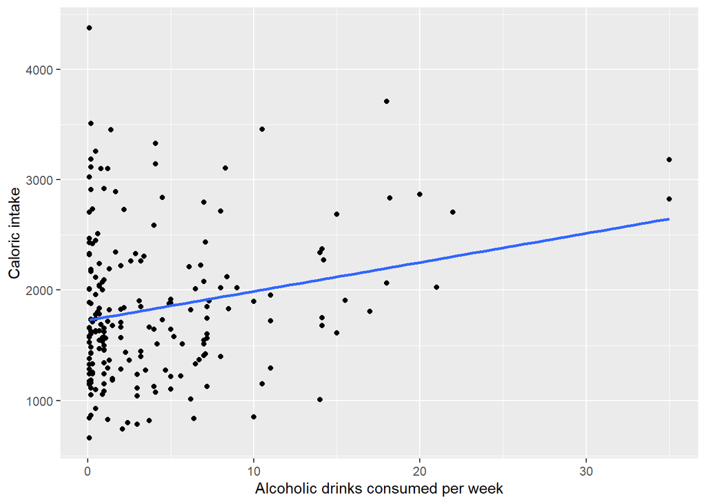

```r
dat %>%
  ggplot(mapping = aes(x = Alcohol,y = Calories)) + geom_point() + stat_smooth(method = "lm",se =   FALSE) +labs(x = "Alcoholic drinks consumed per week", y= "Caloric intake")
```

```r
mod.fit %>%
  glance() %>%
  select(r.squared, adj.r.squared)
```

```
## # A tibble: 1 x 2
##   r.squared adj.r.squared
##       <dbl>         <dbl>
## 1    0.0500        0.0453
```

```r
mod.fit %>%
  broom::augment()
```

```
## # A tibble: 203 x 8
##    Calories Alcohol .fitted .resid .std.resid    .hat .sigma   .cooksd
##       <dbl>   <dbl>   <dbl>  <dbl>      <dbl>   <dbl>  <dbl>     <dbl>
##  1    2372.    14.1   2097.  275.      0.429  0.0204    650. 0.00192
##  2    2450.     0.5   1740.  710.      1.10   0.00692   649. 0.00419
##  3    1367.     1.3   1761. -394.     -0.609  0.00613   650. 0.00114
##  4    1800.     0.6   1742.   58.1     0.0898 0.00681   651. 0.0000276
##  5    1461.     1     1753. -292.     -0.451  0.00640   650. 0.000657
##  6    2073.     0.9   1750.  323.      0.499  0.00650   650. 0.000813
##  7    2868.    20     2252.  617.      0.972  0.0441    649. 0.0218
##  8    1751.    14.1   2097. -346.     -0.538  0.0204    650. 0.00302
##  9    1408.     7     1910. -503.     -0.777  0.00624   650. 0.00190
## 10    1101.     5     1858. -757.     -1.17   0.00505   649. 0.00347
## # ... with 193 more rows
```

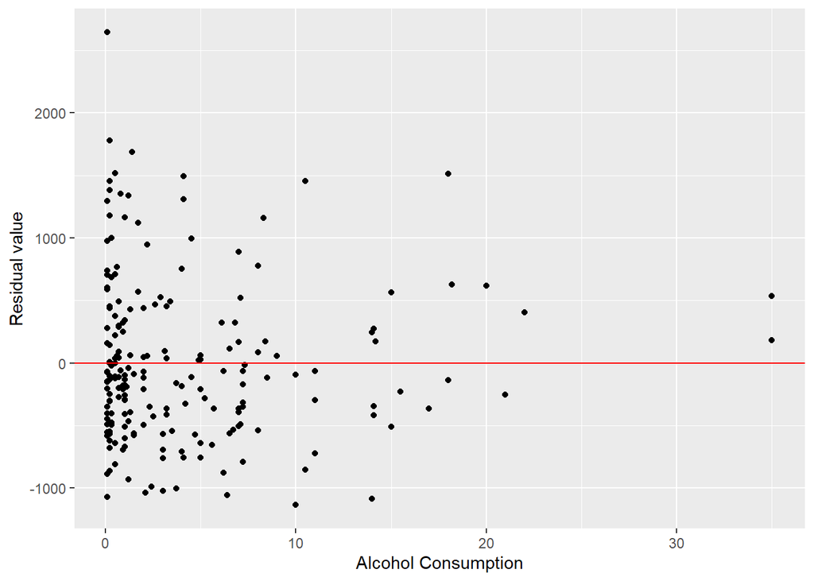

```r
mod.fit %>%
  augment() %>%
  ggplot(mapping = aes(x =Alcohol,y = .resid)) +geom_point() +geom_hline(yintercept = 0,color = "red") +labs(x = "Alcohol Consumption",y = "Residual value")
```

## Results

Calories = 1726.67 + 26.25 x Alcohol Where,
$$B_0 = 1726.67$$
and
$$B_1 = 26.25$$

Here B_0 are the average calories consumed by a person and B_1 calories are expected to increase with each alcoholic drink.

## Conclusion

Since we reject the null hypothesis, as there’s evidence to suggest that drinking more alcohol is related to an increase in number of calories consumed, we can come to a conclusion that with the increase in each drink, approximately 26 calories are increased for the person consuming it.

## References

1. https://www.statsandr.com/blog/correlation-coefficient-and-correlation-test-in-r/
2. https://stackoverflow.com/questions/15016723/create-categories-by-comparing-a-numeric-column-with-a-fixed-value